# Linear Regression-1

MGinorio

11/3/2021

```r
library(tidyverse)
library(moderndive)
library(skimr)
library(ISLR)
library(tinytex)
```

## Dataset

**evals dataset**

Researchers at the University of Texas in Austin, Texas (UT Austin) tried to answer the following research question: what factors explain differences in instructor teaching evaluation scores?

To this end, they collected instructor and course information on 463 courses. A full description of the study can be found at openintro.org.

```r
glimpse(evals)
```

```
## Rows: 463
## Columns: 14
## $ ID           <int> 1, 2, 3, 4, 5, 6, 7, 8, 9, 10, 11, 12, 13, 14, 15, 16, 17~
## $ prof_ID      <int> 1, 1, 1, 1, 2, 2, 2, 3, 3, 4, 4, 4, 4, 4, 4, 4, 4, 5, 5, ~
## $ score        <dbl> 4.7, 4.1, 3.9, 4.8, 4.6, 4.3, 2.8, 4.1, 3.4, 4.5, 3.8, 4.~
## $ age          <int> 36, 36, 36, 36, 59, 59, 59, 51, 51, 40, 40, 40, 40, 40, 4~
## $ bty_avg      <dbl> 5.000, 5.000, 5.000, 5.000, 3.000, 3.000, 3.000, 3.333, 3~
## $ gender       <fct> female, female, female, female, male, male, male, male, m~
## $ ethnicity    <fct> minority, minority, minority, minority, not minority, not~
## $ language     <fct> english, english, english, english, english, english, eng~
## $ rank         <fct> tenure track, tenure track, tenure track, tenure track, t~
## $ pic_outfit   <fct> not formal, not formal, not formal, not formal, not forma~
## $ pic_color    <fct> color, color, color, color, color, color, color, color, c~
## $ cls_did_eval <int> 24, 86, 76, 77, 17, 35, 39, 55, 111, 40, 24, 24, 17, 14, ~
## $ cls_students <int> 43, 125, 125, 123, 20, 40, 44, 55, 195, 46, 27, 25, 20, 2~
## $ cls_level    <fct> upper, upper, upper, upper, upper, upper, upper, upper, u~
```

### Question

Can we explain differences in teaching evaluation score based on various teacher attributes?

### Variables

$y:$ Average teaching $score$ based on students evaluations

$\vec{x}$ Attributes like gender, age, bty_avg

Investigate correlation between this variables

- ID
- Score
- beauty average
- Age

```r
evals_disc11 <- evals %>%
  select(ID, score, bty_avg, age)

evals_disc11
```

```
## # A tibble: 463 x 4
##       ID score bty_avg   age
##    <int> <dbl>   <dbl> <int>
##  1     1   4.7    5       36
##  2     2   4.1    5       36
##  3     3   3.9    5       36
##  4     4   4.8    5       36
##  5     5   4.6    3       59
##  6     6   4.3    3       59
##  7     7   2.8    3       59
##  8     8   4.1    3.33    51
##  9     9   3.4    3.33    51
## 10    10   4.5    3.17    40
## # ... with 453 more rows
```

### EDA

Always perform an exploratory analysis of your variables before any formal modeling

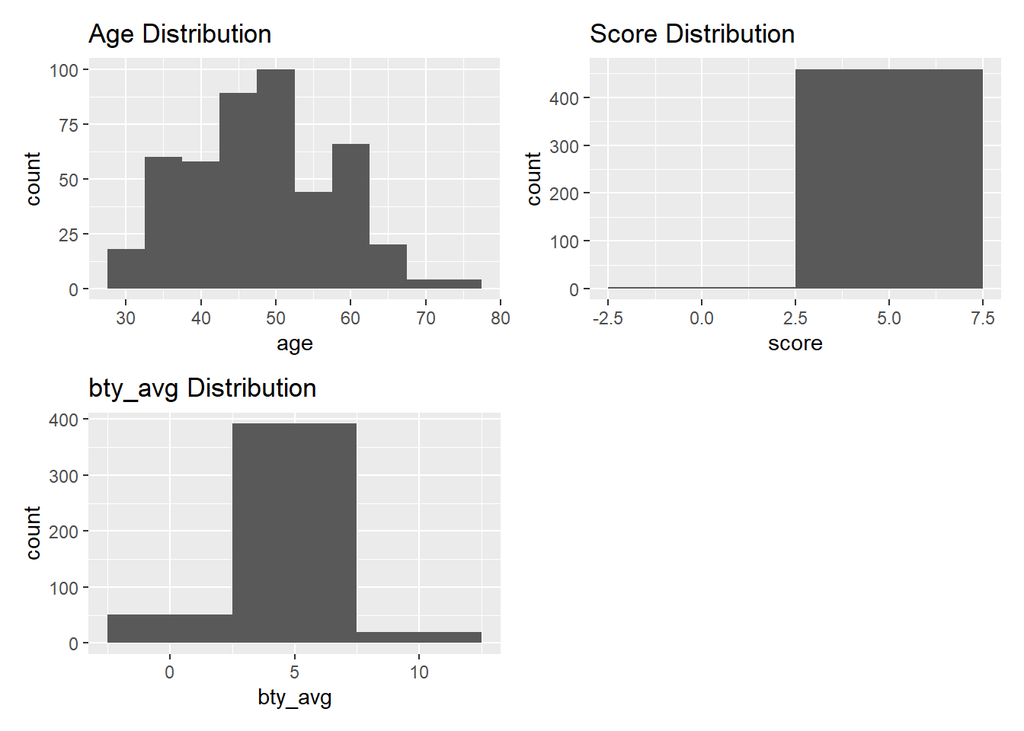

Random sample of 10 out of the 463 courses at UT Ausitn

```r
evals_disc11 %>%
  sample_n(size = 10)
```

```
## # A tibble: 10 x 4
##       ID score bty_avg   age
##    <int> <dbl>   <dbl> <int>
##  1   191   4.3    2.33    54
##  2   234   4.5    4.83    61
##  3   318   4      6.5     52
##  4   283   3.8    1.67    34
##  5   394   4.8    3.33    45
##  6    31   4.4    4.17    33
##  7   380   3.6    2.5     38
##  8   119   3.9    4.33    57
##  9    48   4.7    4.67    33
## 10   207   4.7    3       62
```

### Statistics

```r
evals_disc11 %>%
  select(score, bty_avg, age) %>% skim()
```

Data summary

| Name | Piped data |
| --- | --- |
| Number of rows | 463 |
| Number of columns | 3 |
| _______________________ |  |
| Column type frequency: |  |
| numeric | 3 |
| ________________________ |  |
| Group variables | None |

**Variable type: numeric**

| skim_variable | n_missing | complete_rate | mean | sd | p0 | p25 | p50 | p75 | p100 | hist |
| --- | --- | --- | --- | --- | --- | --- | --- | --- | --- | --- |
| score | 0 | 1 | 4.17 | 0.54 | 2.30 | 3.80 | 4.30 | 4.6 | 5.00 | ▁▁▅▇▇ |
| bty_avg | 0 | 1 | 4.42 | 1.53 | 1.67 | 3.17 | 4.33 | 5.5 | 8.17 | ▃▇▇▃▂ |
| age | 0 | 1 | 48.37 | 9.80 | 29.00 | 42.00 | 48.00 | 57.0 | 73.00 | ▅▆▇▆▁ |

### Correlation Coefficient

- formula
- = score ~ bty_avg
- = score ~ age

```
## # A tibble: 1 x 1
##     cor
##   <dbl>
## 1 0.187
```

```
## # A tibble: 1 x 1
##      cor
##    <dbl>
## 1 -0.107
```

**Visual Relationship**

We can see their relationship is consistent with the coefficient sign and result

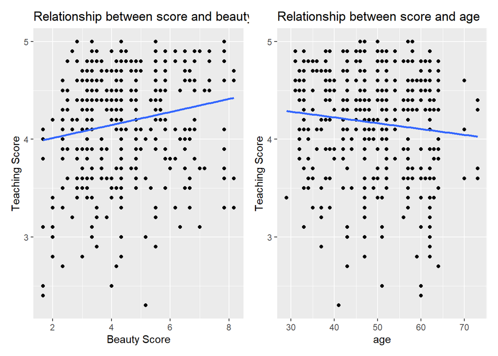

Regression line is consistent with the earlier result of correlation coefficient 0.187

**as instructors have higher beauty scores they receive higher teacher evaluations**

### Residuals

**Score Model**

| term | estimate | std_error | statistic | p_value | lower_ci | upper_ci |
| --- | --- | --- | --- | --- | --- | --- |
| intercept | 3.880 | 0.076 | 50.961 | 0 | 3.683 | 4.077 |
| bty_avg | 0.067 | 0.016 | 4.090 | 0 | 0.024 | 0.109 |

### Conditions for Linear Regression

**Visual Relationship**

Distribution of Residuals Investigate potential relationships between the residuals and all explanatory/predictor variables

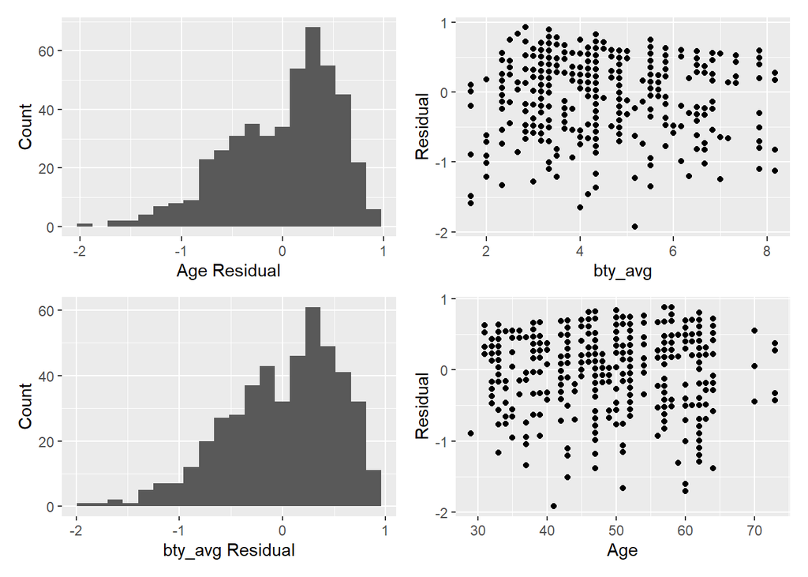

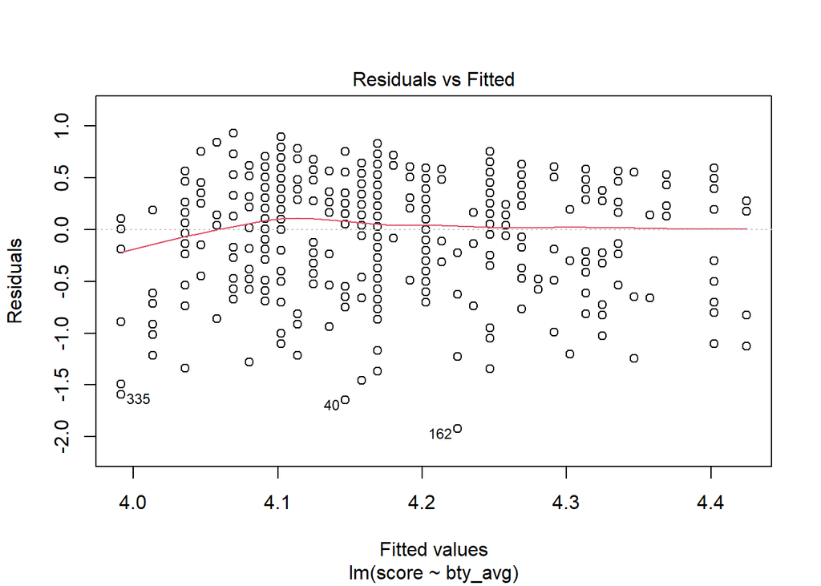

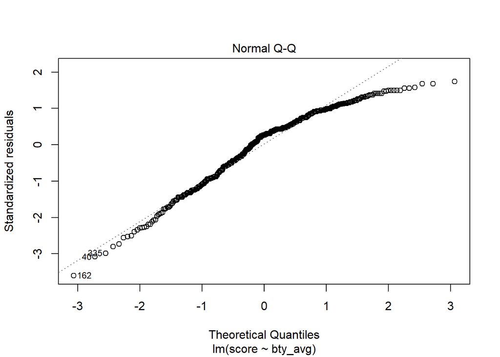

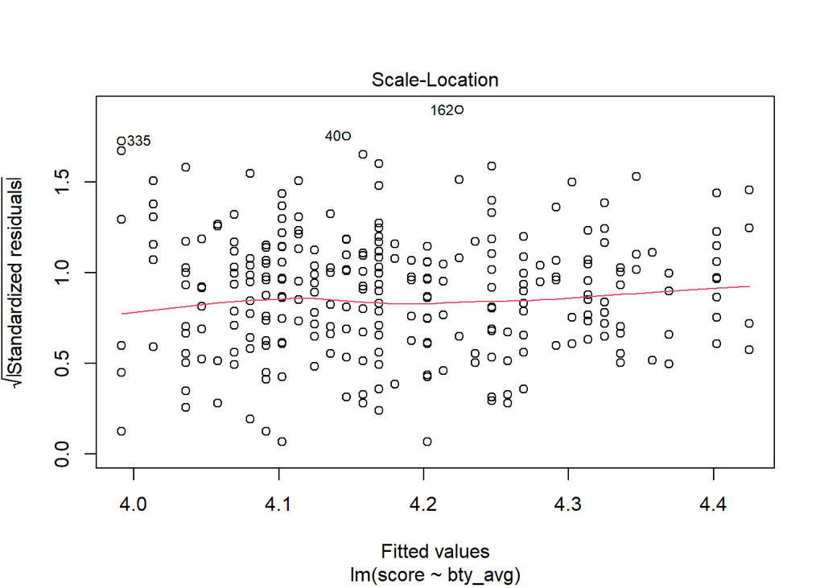

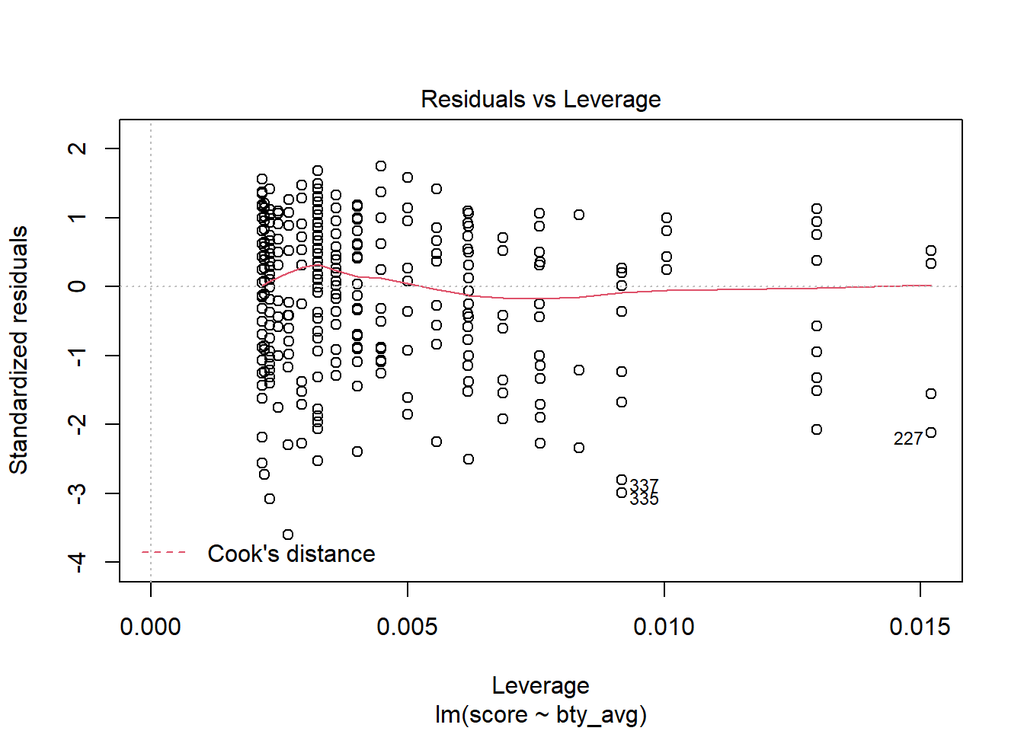

```r
plot(score_model)
```

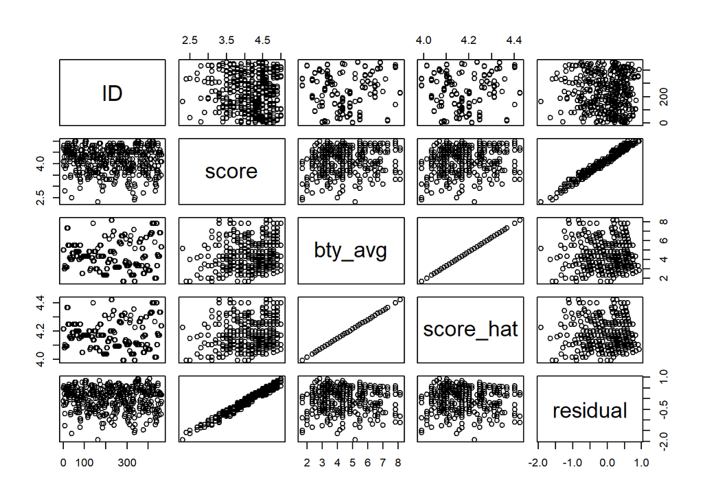

```r
plot(score_model_points)
```

### Fit Model

$$\hat{y} = b_0 + b_1 * x$$

$$\hat{score} = b_0 + b_1 * bty.avg$$

$$\hat{score} = 3.880 + 0.067 * bty.avg$$

Relationship between teaching and beauty = $b_1 = 0.067$

**Note**

- Sign is positive
- positive relationship
- **teachers with higher beauty tend to have higher teaching scores**
- Correlation Coefficient 0.187 is positive
- slope $b_1 = 0.067$ interpretation

**Note**

- score = y
- bty_avg = $x$
- score_hat = $\hat{y}$
- residual = $y-\hat{y}$

## Conclusion

**sum of squared residuals**

if we compute the residuals for all 463 courses’ instructors and compute the sum of squared residuals we would obtain the “lack of a fit in a model”

$$y - \hat{y} = 0$$

```r
# compute the square of residuals

score_model_points %>%
  mutate(squared_residuals = residual^2) %>%
  summarise(sum_of_squared_residuals = sum(squared_residuals))
```

```
## # A tibble: 1 x 1
##   sum_of_squared_residuals
##                      <dbl>
## 1                     132.
```